# BigMart Sales Analysis

### 5. Sales by Location Tier

```r
sales_by_location <- read_csv(here("data", "processed", "sales_by_location.csv"))
```

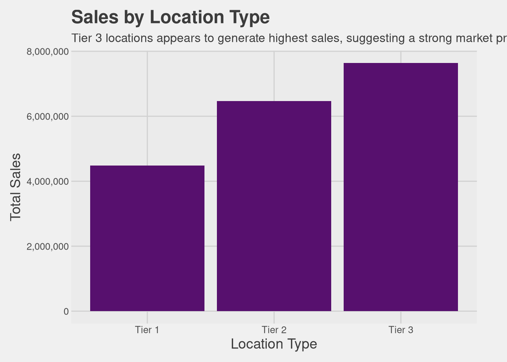

```r
sales_by_location %>%
  ggplot(aes(x = outlet_location_type, y = total_sales)) +
  geom_col(fill = "#57106EFF") +
  scale_y_continuous(labels = scales::comma) +
  labs(
    title = "Sales by Location Type",
    subtitle = "Tier 3 locations appears to generate highest sales, suggesting a strong market presence in suburban or rural zones",
    x = "Location Type",
    y = "Total Sales"
  ) +
  theme_fivethirtyeight() +
  theme(
    text = element_text(family = "sans"),
    plot.title = element_text(size = 18, face = "bold"),
    axis.title = element_text(size = 14),
    axis.text = element_text(),
    plot.margin = margin(10, 30, 10, 10)
  )
```

Tier 3 locations generate the highest sales, indicating strong performance in non-urban markets.

### 6. Sales by Category

```r
sales_by_category <- read_csv(here("data", "processed", "sales_by_category.csv"))
```

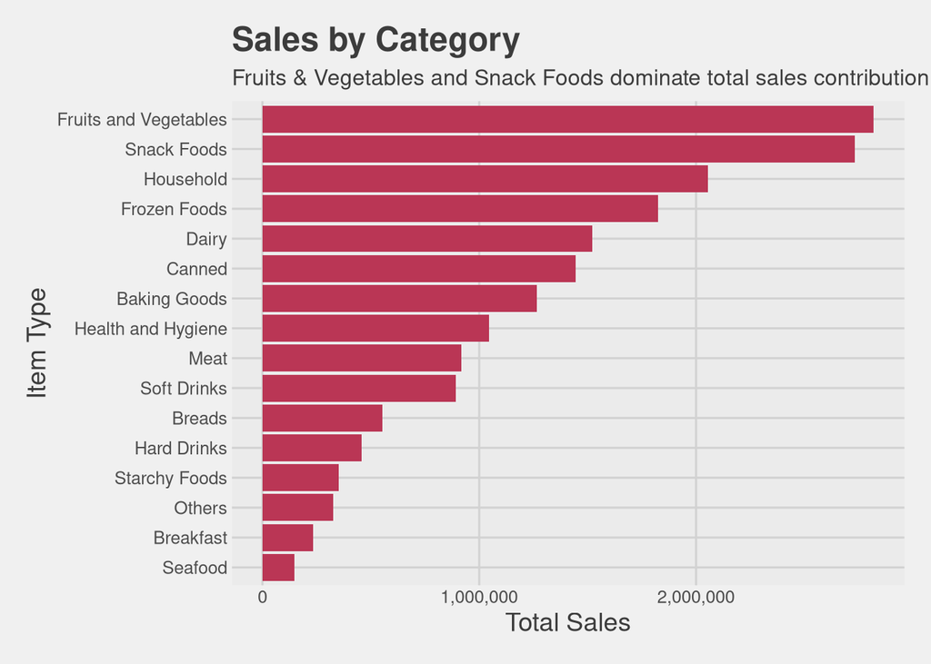

```r
sales_by_category %>%
  ggplot(aes(x = reorder(item_type, total_sales), y = total_sales)) +
  geom_col(fill = "#BA3655FF") +
  scale_y_continuous(labels = scales::comma) +
  coord_flip() +
  labs(
    title = "Sales by Category",
    subtitle = "Fruits & Vegetables and Snack Foods dominate total sales contribution",
    x = "Item Type",
    y = "Total Sales"
  ) +
  theme_fivethirtyeight() +
  theme(
    text = element_text(family = "sans"),
    plot.title = element_text(size = 18, face = "bold"),
    axis.title = element_text(size = 14),
    axis.text = element_text()
  )
```

Fruits & Vegetables and Snack Foods dominate total sales contribution.

### 7. Sales by Fat Content

```r
sales_by_fat <- read_csv(here("data", "processed", "sales_by_fat.csv"))
```

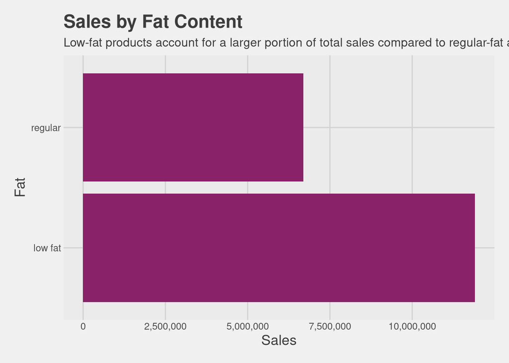

```r
sales_by_fat %>%
  ggplot(aes(x = item_fat_content, y = total_sales)) +
  geom_col(fill = "#8A226AFF") +
  scale_y_continuous(labels = scales::comma) +
  coord_flip() +
  labs(
    title = "Sales by Fat Content",
    subtitle = "Low-fat products account for a larger portion of total sales compared to regular-fat alternatives",
    x = "Fat",
    y = "Sales"
  ) +
  theme_fivethirtyeight() +
  theme(
    text = element_text(family = "sans"),
    plot.title = element_text(size = 18, face = "bold"),
    axis.title = element_text(size =14),
    axis.text = element_text()
  )
```

Low-fat products contribute more to total sales than regular-fat products.

# 6. Key Insights

- Sales are heavily skewed toward a small number of high-performing products
- Higher MRP items tend to generate more revenue
- Visibility has limited impact on sales performance
- Supermarket Type 1 dominates total sales
- Tier 3 locations outperform urban areas
- Certain product categories contribute disproportionately to revenue

# 7. Business Recommendations

- Focus inventory on high-performing product categories
- Expand operations in Tier 3 locations
- Optimize pricing strategies for premium products
- Improve performance of underperforming outlet types

# 8. Conclusion

This analysis highlights key drivers of retail performance and provides actionable insights for improving sales strategy and operational efficiency across BigMart outlets.

[output not shown]